# Dostep do sluzby zdrowia a dynamika zakazen

AJ

23/11/2021

Polska przestrzennie: zakazenia, zgony, seroprewalencja a HCA

PctExp- wyjaśniana zmienność

Model regresji czynnikowej z interakcjami na poziomie województw (rzutowanie -zmienna wyjaśniani na seroprewalencję >20 lat z pierwszej tury Obser-co)

```r
mod_sero=lm(obser_cov~ case_3rd_wave+case_3rd_wave*HeathCareAccess_per_w+HeathCareAccess_w*case_3rd_wave+case_3rd_wave*HeathCareAccess_per_w*proc_vac_full_w, data=woj_com)

af <- anova(mod_sero)
afss <- af$"Sum Sq"
proc_sero<-cbind(af,PctExp=afss/sum(afss)*100)

proc_sero
```

```
##                                                     Df      Sum Sq    Mean Sq
## case_3rd_wave                                        1  91.1789777 91.1789777
## HeathCareAccess_per_w                                1   0.5958226  0.5958226
## HeathCareAccess_w                                    1  11.7476785 11.7476785
## proc_vac_full_w                                      1   6.0493653  6.0493653
## case_3rd_wave:HeathCareAccess_per_w                  1  40.8244210 40.8244210
## case_3rd_wave:HeathCareAccess_w                      1   1.7270948  1.7270948
## case_3rd_wave:proc_vac_full_w                        1   1.7273603  1.7273603
## HeathCareAccess_per_w:proc_vac_full_w                1   2.3277386  2.3277386
## case_3rd_wave:HeathCareAccess_per_w:proc_vac_full_w  1   6.2489771  6.2489771
## Residuals                                            6 188.1425642 31.3570940
##                                                        F value    Pr(>F)
## case_3rd_wave                                       2.90776236 0.1390347
## HeathCareAccess_per_w                               0.01900121 0.8948727
## HeathCareAccess_w                                   0.37464181 0.5629456
## proc_vac_full_w                                     0.19291855 0.6758751
## case_3rd_wave:HeathCareAccess_per_w                 1.30191978 0.2973492
## case_3rd_wave:HeathCareAccess_w                     0.05507828 0.8222551
## case_3rd_wave:proc_vac_full_w                       0.05508675 0.8222417
## HeathCareAccess_per_w:proc_vac_full_w               0.07423324 0.7944038
## case_3rd_wave:HeathCareAccess_per_w:proc_vac_full_w 0.19928432 0.6709588
## Residuals                                                   NA        NA
##                                                         PctExp
## case_3rd_wave                                       26.0087793
## HeathCareAccess_per_w                                0.1699582
## HeathCareAccess_w                                    3.3510222
## proc_vac_full_w                                      1.7255798
## case_3rd_wave:HeathCareAccess_per_w                 11.6451553
## case_3rd_wave:HeathCareAccess_w                      0.4926533
## case_3rd_wave:proc_vac_full_w                        0.4927291
## HeathCareAccess_per_w:proc_vac_full_w                0.6639868
## case_3rd_wave:HeathCareAccess_per_w:proc_vac_full_w  1.7825191
## Residuals                                           53.6676168
```

Dlategi dobrą zmienną pośrednicząca między skumulowaną liczbą zakażeń a wynikami serologicznymi (realizowanymi na wczesnym etapie szczepień populacyjnych) jest dostępność do podażowa służby zdrowia.

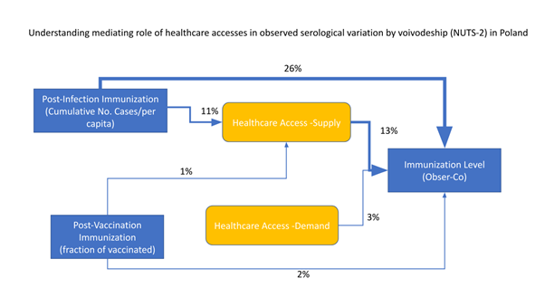

```r
knitr::include_graphics("sero_diag.png", dpi=100)
```

model regresji czynnikowej z interakcjami na poziomie powiatów (rzutowanie - zmienna wyjaśniana na liczbę przypadków w drugiej połowie września)

Specjalnie wybraliiśmy ostatnie 2 tygodnie września/przełom pażdziernika jako w miarę niezależny od dochodu (już importowane przypadki z wakacji nie powinny wpływać za bardzo a zaraz zaczną się ogniska w ośrodkach akademickich, które zaburzą obraz).

```r
mod_zakazenia=lm(inf_autumn~vacc_+ HealthCareAcc*size_COVID+vacc_* HealthCareAcc*size_COVID*HealthAcc_phys, data=vacc_sel_norm)

af <- anova(mod_zakazenia)
afss <- af$"Sum Sq"
proc_zakazenia<-cbind(af,PctExp=afss/sum(afss)*100)
proc_zakazenia
```

```
##                                                Df      Sum Sq    Mean Sq
## vacc_                                           1    907627.0   907627.0
## HealthCareAcc                                   1  29036881.9 29036881.9
## size_COVID                                      1    196550.3   196550.3
## HealthAcc_phys                                  1   6761886.7  6761886.7
## HealthCareAcc:size_COVID                        1    701024.4   701024.4
## vacc_:HealthCareAcc                             1   1682603.0  1682603.0
## vacc_:size_COVID                                1   5524342.4  5524342.4
## vacc_:HealthAcc_phys                            1    269372.4   269372.4
## HealthCareAcc:HealthAcc_phys                    1   1055608.1  1055608.1
## size_COVID:HealthAcc_phys                       1    332017.8   332017.8
## vacc_:HealthCareAcc:size_COVID                  1   3988735.8  3988735.8
## vacc_:HealthCareAcc:HealthAcc_phys              1   1009559.3  1009559.3
## vacc_:size_COVID:HealthAcc_phys                 1   1633747.5  1633747.5
## HealthCareAcc:size_COVID:HealthAcc_phys         1    983356.7   983356.7
## vacc_:HealthCareAcc:size_COVID:HealthAcc_phys   1   1503256.5  1503256.5
## Residuals                                     364 143437017.3   394057.7
##                                                  F value       Pr(>F)
## vacc_                                          2.3032842 1.299688e-01
## HealthCareAcc                                 73.6868712 2.697690e-16
## size_COVID                                     0.4987856 4.804860e-01
## HealthAcc_phys                                17.1596342 4.276569e-05
## HealthCareAcc:size_COVID                       1.7789889 1.831075e-01
## vacc_:HealthCareAcc                            4.2699402 3.949919e-02
## vacc_:size_COVID                              14.0191190 2.102636e-04
## vacc_:HealthAcc_phys                           0.6835860 4.088963e-01
## HealthCareAcc:HealthAcc_phys                   2.6788157 1.025556e-01
## size_COVID:HealthAcc_phys                      0.8425612 3.592731e-01
## vacc_:HealthCareAcc:size_COVID                10.1222116 1.590810e-03
## vacc_:HealthCareAcc:HealthAcc_phys             2.5619579 1.103304e-01
## vacc_:size_COVID:HealthAcc_phys                4.1459596 4.245750e-02
## HealthCareAcc:size_COVID:HealthAcc_phys        2.4954635 1.150433e-01
## vacc_:HealthCareAcc:size_COVID:HealthAcc_phys  3.8148129 5.156715e-02
## Residuals                                             NA           NA
##                                                   PctExp
## vacc_                                          0.4560399
## HealthCareAcc                                 14.5896687
## size_COVID                                     0.0987573
## HealthAcc_phys                                 3.3975303
## HealthCareAcc:size_COVID                       0.3522318
## vacc_:HealthCareAcc                            0.8454289
## vacc_:size_COVID                               2.7757224
## vacc_:HealthAcc_phys                           0.1353470
## HealthCareAcc:HealthAcc_phys                   0.5303934
## size_COVID:HealthAcc_phys                      0.1668233
## vacc_:HealthCareAcc:size_COVID                 2.0041523
## vacc_:HealthCareAcc:HealthAcc_phys             0.5072561
## vacc_:size_COVID:HealthAcc_phys                0.8208813
## HealthCareAcc:size_COVID:HealthAcc_phys        0.4940905
## vacc_:HealthCareAcc:size_COVID:HealthAcc_phys  0.7553158
## Residuals                                     72.0703609
```

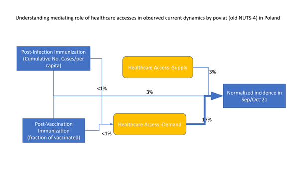

```r
knitr::include_graphics("zak_diag.png", dpi=100)
```

Model regresji czynnikowej z interakcjami na poziomie powiatów (rzutowanie - zmienna wyjaśniana na liczbę zgonów 15.09-21.11)

```r
mod_zgony=lm(deaths_norm~vacc_+ HealthCareAcc*size_COVID+vacc_* HealthCareAcc*size_COVID*HealthAcc_phys, data=vacc_zgony)


af <- anova(mod_zgony)
afss <- af$"Sum Sq"
proc_zgony<-cbind(af,PctExp=afss/sum(afss)*100)
proc_zgony
```

```
##                                                Df       Sum Sq      Mean Sq
## vacc_                                           1 1.226278e+06 1226277.8885
## HealthCareAcc                                   1 2.059949e+06 2059949.1840
## size_COVID                                      1 4.201568e+05  420156.8326
## HealthAcc_phys                                  1 4.743787e+05  474378.6583
## HealthCareAcc:size_COVID                        1 2.281876e+03    2281.8762
## vacc_:HealthCareAcc                             1 5.859061e+04   58590.6059
## vacc_:size_COVID                                1 3.804668e+05  380466.8051
## vacc_:HealthAcc_phys                            1 1.090207e+03    1090.2069
## HealthCareAcc:HealthAcc_phys                    1 4.841303e+03    4841.3025
## size_COVID:HealthAcc_phys                       1 2.278919e+05  227891.8595
## vacc_:HealthCareAcc:size_COVID                  1 7.866217e+04   78662.1720
## vacc_:HealthCareAcc:HealthAcc_phys              1 7.031494e+02     703.1494
## vacc_:size_COVID:HealthAcc_phys                 1 8.218865e+04   82188.6494
## HealthCareAcc:size_COVID:HealthAcc_phys         1 1.045514e+05  104551.3849
## vacc_:HealthCareAcc:size_COVID:HealthAcc_phys   1 1.271408e+05  127140.7693
## Residuals                                     364 1.390726e+07   38206.7536
##                                                   F value       Pr(>F)
## vacc_                                         32.09584099 2.985494e-08
## HealthCareAcc                                 53.91583921 1.381620e-12
## size_COVID                                    10.99692575 1.004504e-03
## HealthAcc_phys                                12.41609437 4.798666e-04
## HealthCareAcc:size_COVID                       0.05972442 8.070697e-01
## vacc_:HealthCareAcc                            1.53351437 2.163838e-01
## vacc_:size_COVID                               9.95810345 1.734836e-03
## vacc_:HealthAcc_phys                           0.02853440 8.659524e-01
## HealthCareAcc:HealthAcc_phys                   0.12671327 7.220707e-01
## size_COVID:HealthAcc_phys                      5.96470095 1.507016e-02
## vacc_:HealthCareAcc:size_COVID                 2.05885517 1.521824e-01
## vacc_:HealthCareAcc:HealthAcc_phys             0.01840380 8.921646e-01
## vacc_:size_COVID:HealthAcc_phys                2.15115501 1.433261e-01
## HealthCareAcc:size_COVID:HealthAcc_phys        2.73646345 9.894363e-02
## vacc_:HealthCareAcc:size_COVID:HealthAcc_phys  3.32770407 6.894161e-02
## Residuals                                              NA           NA
##                                                     PctExp
## vacc_                                          6.401390606
## HealthCareAcc                                 10.753304352
## size_COVID                                     2.193294054
## HealthAcc_phys                                 2.476341713
## HealthCareAcc:size_COVID                       0.011911803
## vacc_:HealthCareAcc                            0.305853475
## vacc_:size_COVID                               1.986104989
## vacc_:HealthAcc_phys                           0.005691076
## HealthCareAcc:HealthAcc_phys                   0.025272468
## size_COVID:HealthAcc_phys                      1.189636397
## vacc_:HealthCareAcc:size_COVID                 0.410630652
## vacc_:HealthCareAcc:HealthAcc_phys             0.003670566
## vacc_:size_COVID:HealthAcc_phys                0.429039497
## HealthCareAcc:size_COVID:HealthAcc_phys        0.545776989
## vacc_:HealthCareAcc:size_COVID:HealthAcc_phys  0.663697628
## Residuals                                     72.598383736
```

Dobrą zmienną wyjaśniającą umieralność jest dostępność popytowa do służby zdrowia. Poziom zaszczepienia (6%) czy skumulowana liczba zakaźeń na miekszańca w poprzednich falach (2%), mają istotne znaczenie, ale wciąż dostęp popytowy do służby zdrowia jest najważniejszy (12%).

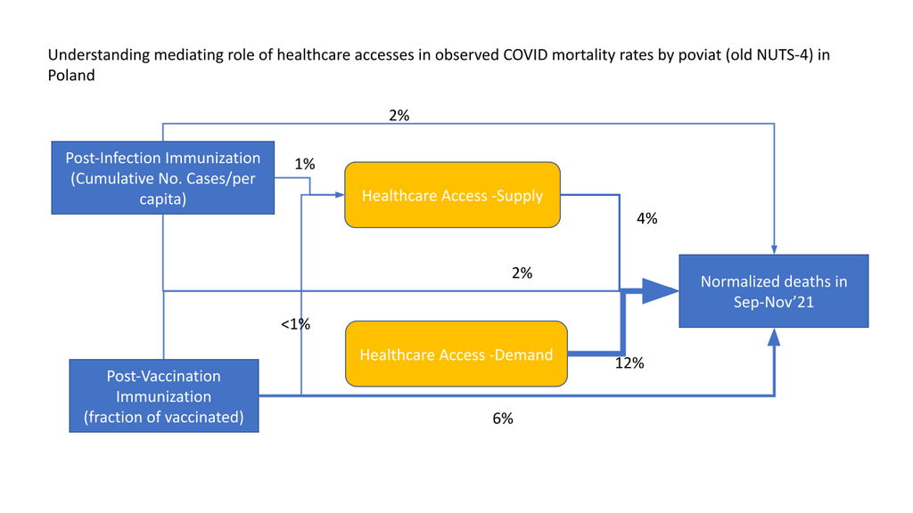

```r
knitr::include_graphics("current_deaths.png", dpi=200)
```

#Dodatowe analizy diagnostyczne

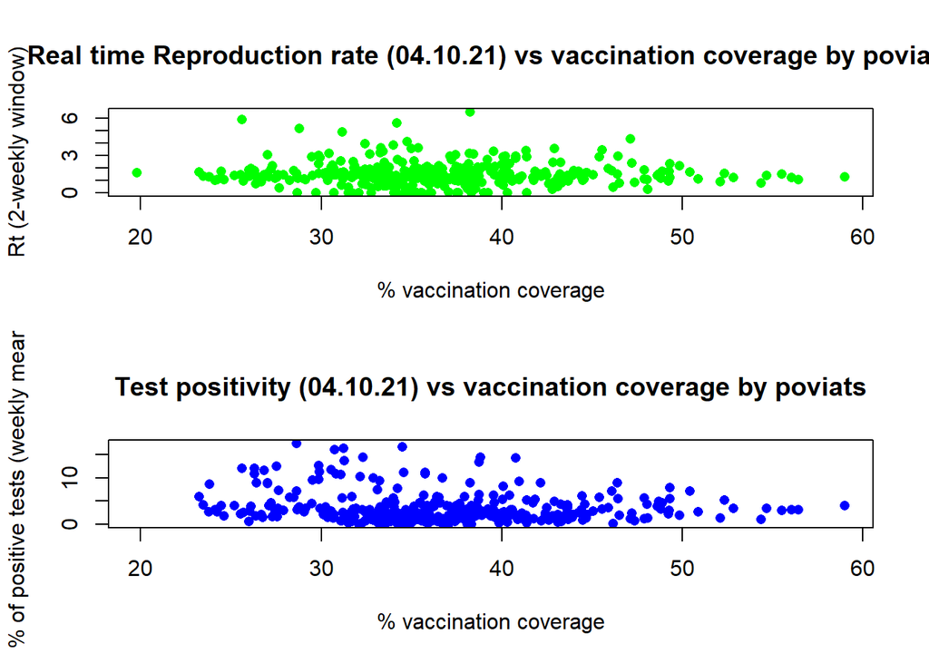

```r
par(mfrow=c(2,1))


plot(vacc_sel_norm$vacc_*100, vacc_sel_norm$rt, main = "Real time Reproduction rate (04.10.21) vs vaccination coverage by poviats", ylab = "Rt (2-weekly window)", xlab = "% vaccination coverage", pch=16, col="green")


plot(vacc_sel_norm$vacc_*100, vacc_sel_norm$tests, main = "Test positivity (04.10.21) vs vaccination coverage by poviats", ylab = "% of positive tests (weekly mean)", xlab = "% vaccination coverage", pch=16, col="blue")
```

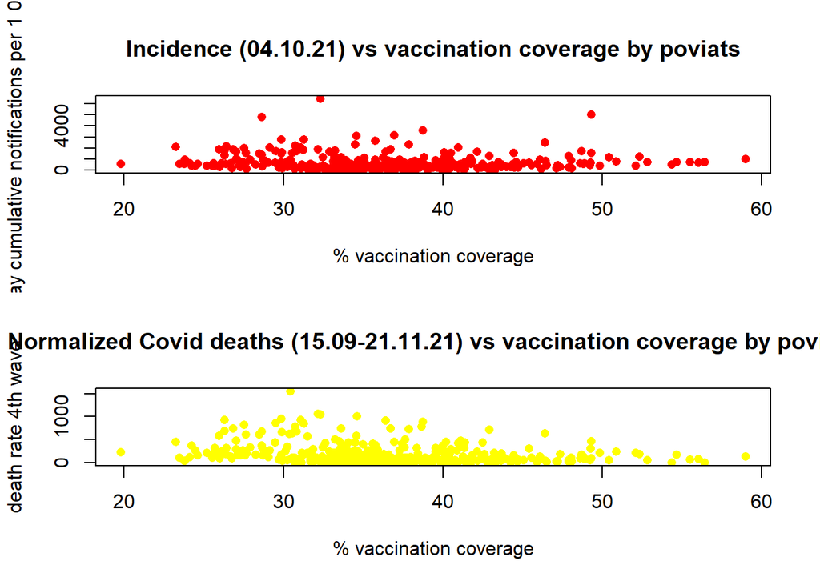

```r
par(mfrow=c(2,1))

plot(vacc_sel_norm$vacc_*100, vacc_sel_norm$inf_autumn, main = "Incidence (04.10.21) vs vaccination coverage by poviats", ylab = "14day cumulative notifications per 1 000 000", xlab = "% vaccination coverage", pch=16, col="red")

plot(vacc_zgony$vacc_*100, vacc_zgony$deaths_norm, main = "Normalized Covid deaths (15.09-21.11.21) vs vaccination coverage by poviats", ylab = "death rate 4th wave", xlab = "% vaccination coverage", pch=16, col="yellow")
```

Należy zauważyć, że obecna 4-ta fala w ujęciu powiatowym nie koreluje ani z poziomem wyszczepienia (wykresy różnych zmiennych opisujących aktualną dynamikę), ani oficjalną notowabą odpornością pochorobową. Jedynie udział osób zaszczepionych jest związany z umieralnością na COVID w 4-tej fali i ją redukuje. Trzeba jednak pamiętać, że to zależy też od dostępu do ochrony zdrowia, poziomu odporności po przechorowaniu czy innych czynników jak demografia.

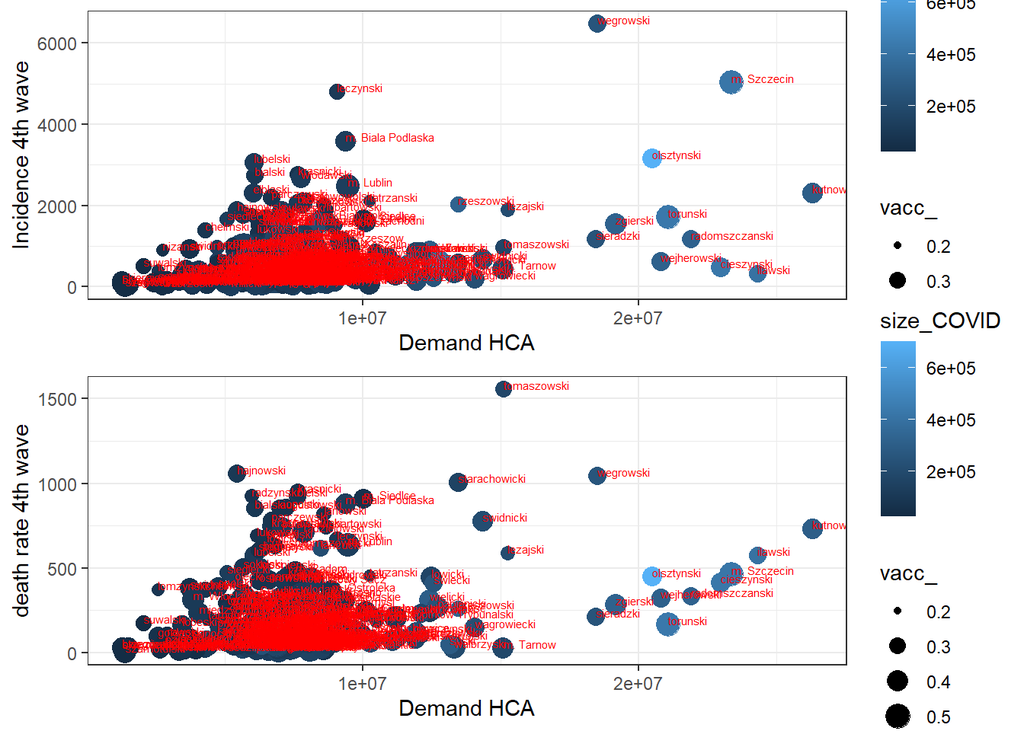

```r
vacc_zgony2=vacc_zgony[which(vacc_zgony$deaths>0),]

pl_inf<-ggplot(vacc_zgony, aes(HealthCareAcc,inf_autumn, size=vacc_, color=size_COVID)) + theme_bw()+
  geom_point() + xlab("Demand HCA")+ylab("Incidence 4th wave") +geom_text(aes(label=county),hjust=0, vjust=0, color="red", size=2)

pl_death <- ggplot(vacc_zgony2, aes(HealthCareAcc,deaths_norm, size=vacc_, color=size_COVID)) + theme_bw()+
  geom_point() + xlab("Demand HCA")+ylab("death rate 4th wave") +geom_text(aes(label=county),hjust=0, vjust=0, color="red", size=2)

ggarrange(pl_inf, pl_death)
```

Dynamika zakażeń (zapadalność i zgony) zależą w dużej mierze od dostępności popytowej do służby zdrowia, ale w sposób nieliowy

```r
mod_zgony2=lm(deaths_norm~vacc_+ I(HealthCareAcc*HealthCareAcc)+ HealthCareAcc*size_COVID+vacc_* HealthCareAcc*size_COVID*HealthAcc_phys, data=vacc_zgony)


af <- anova(mod_zgony2)
afss <- af$"Sum Sq"
proc_zgony2<-cbind(af,PctExp=afss/sum(afss)*100)
proc_zgony2
```

```
##                                                Df       Sum Sq      Mean Sq
## vacc_                                           1 1.226278e+06 1226277.8885
## I(HealthCareAcc * HealthCareAcc)                1 1.788990e+06 1788990.2479
## HealthCareAcc                                   1 2.807765e+05  280776.4907
## size_COVID                                      1 4.105214e+05  410521.4133
## HealthAcc_phys                                  1 4.756489e+05  475648.9241
## HealthCareAcc:size_COVID                        1 1.831891e+04   18318.9081
## vacc_:HealthCareAcc                             1 5.558021e+04   55580.2102
## vacc_:size_COVID                                1 3.694853e+05  369485.3419
## vacc_:HealthAcc_phys                            1 9.097460e+02     909.7460
## HealthCareAcc:HealthAcc_phys                    1 7.122597e+03    7122.5966
## size_COVID:HealthAcc_phys                       1 2.286309e+05  228630.8662
## vacc_:HealthCareAcc:size_COVID                  1 9.093108e+04   90931.0783
## vacc_:HealthCareAcc:HealthAcc_phys              1 8.450015e+02     845.0015
## vacc_:size_COVID:HealthAcc_phys                 1 7.522590e+04   75225.8962
## HealthCareAcc:size_COVID:HealthAcc_phys         1 1.599610e+05  159961.0388
## vacc_:HealthCareAcc:size_COVID:HealthAcc_phys   1 1.259148e+05  125914.7609
## Residuals                                     363 1.384129e+07   38130.2734
##                                                   F value       Pr(>F)
## vacc_                                         32.16021756 2.901357e-08
## I(HealthCareAcc * HealthCareAcc)              46.91784474 3.178198e-11
## HealthCareAcc                                  7.36361074 6.973037e-03
## size_COVID                                    10.76628559 1.133849e-03
## HealthAcc_phys                                12.47431192 4.657751e-04
## HealthCareAcc:size_COVID                       0.48042950 4.886711e-01
## vacc_:HealthCareAcc                            1.45763996 2.280921e-01
## vacc_:size_COVID                               9.69007848 1.999641e-03
## vacc_:HealthAcc_phys                           0.02385889 8.773303e-01
## HealthCareAcc:HealthAcc_phys                   0.18679637 6.658531e-01
## size_COVID:HealthAcc_phys                      5.99604581 1.481036e-02
## vacc_:HealthCareAcc:size_COVID                 2.38474761 1.233960e-01
## vacc_:HealthCareAcc:HealthAcc_phys             0.02216091 8.817425e-01
## vacc_:size_COVID:HealthAcc_phys                1.97286538 1.609991e-01
## HealthCareAcc:size_COVID:HealthAcc_phys        4.19511911 4.125944e-02
## vacc_:HealthCareAcc:size_COVID:HealthAcc_phys  3.30222549 7.001049e-02
## Residuals                                              NA           NA
##                                                     PctExp
## vacc_                                          6.401390606
## I(HealthCareAcc * HealthCareAcc)               9.338850088
## HealthCareAcc                                  1.465703660
## size_COVID                                     2.142995436
## HealthAcc_phys                                 2.482972728
## HealthCareAcc:size_COVID                       0.095627987
## vacc_:HealthCareAcc                            0.290138670
## vacc_:size_COVID                               1.928779780
## vacc_:HealthAcc_phys                           0.004749037
## HealthCareAcc:HealthAcc_phys                   0.037181232
## size_COVID:HealthAcc_phys                      1.193494144
## vacc_:HealthCareAcc:size_COVID                 0.474676544
## vacc_:HealthCareAcc:HealthAcc_phys             0.004411059
## vacc_:size_COVID:HealthAcc_phys                0.392692676
## HealthCareAcc:size_COVID:HealthAcc_phys        0.835025324
## vacc_:HealthCareAcc:size_COVID:HealthAcc_phys  0.657297645
## Residuals                                     72.254013383
```

Duże znaczenie ma wyraz kwadratowy dostępności popytowej do służby zdrowia

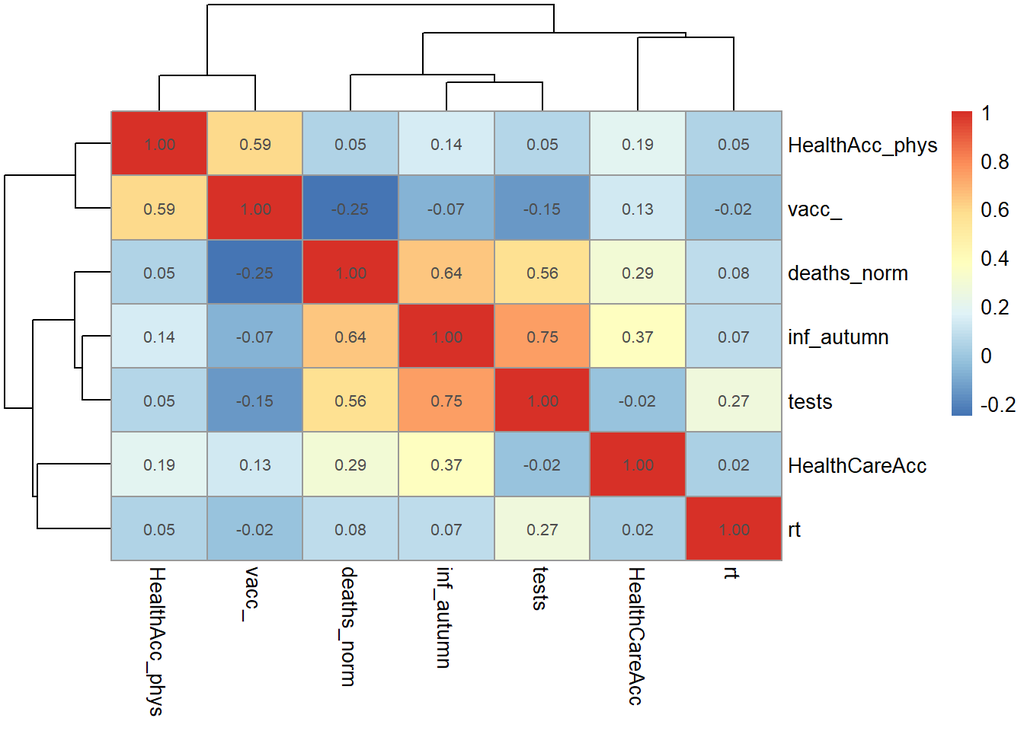

```r
kor=cor(vacc_zgony[,c(14,15,17:20,23)], use="pairwise.complete.obs")
pheatmap(kor, display_numbers = T)
```